# Wikimedia

André Felipe

O objeto principal da análise são as buscas e a navegação depois da busca. Criamos esses dados a partir dos dados originais da wikimedia em `/data/search_data.csv`.

Aqui, exploramos esses dados.

```r
buscas = read_csv(here::here("data/search_data.csv"))
glimpse(buscas)
```

```
Observations: 136,234
Variables: 9
$ session_id              <chr> "0000cbcb67c19c45", "0001382e027b2ea4", "0001e8bb…
$ search_index            <dbl> 1, 1, 1, 1, 2, 3, 4, 5, 6, 1, 1, 2, 1, 1, 1, 1, 1…
$ session_length          <dbl> 0, 303, 435, 58, 58, 58, 58, 58, 58, 0, 43, 43, 0…
$ session_start_timestamp <dbl> 20160303152045, 20160307084955, 20160305092415, 2…
$ session_start_date      <dttm> 2016-03-03 15:20:45, 2016-03-07 08:49:55, 2016-0…
$ group                   <chr> "b", "b", "b", "a", "a", "a", "a", "a", "a", "b",…
$ results                 <dbl> 20, 18, 20, 20, 20, 20, 20, 20, 20, 1, 0, 1, 20, …
$ num_clicks              <dbl> 0, 1, 1, 0, 0, 0, 0, 0, 0, 0, 0, 1, 0, 0, 3, 0, 0…
$ first_click             <dbl> NA, 1, 1, NA, NA, NA, NA, NA, NA, NA, NA, 1, NA, …
```

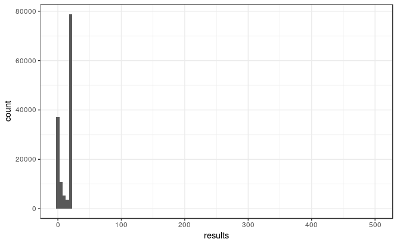

```r
buscas %>%
    ggplot(aes(x = results)) +
    geom_histogram(binwidth = 5)
```

## Você deve criar um relatório reproduzível respondendo às seguintes perguntas:

### 1) Qual é a nossa taxa de cliques geral diária? Como isso varia entre os grupos?

Vamos analisar o número geral de cliques e a média de cliques apenas quando o usuário clica em alguma coisa, ou seja, quando num_clicks > 0 no geral.

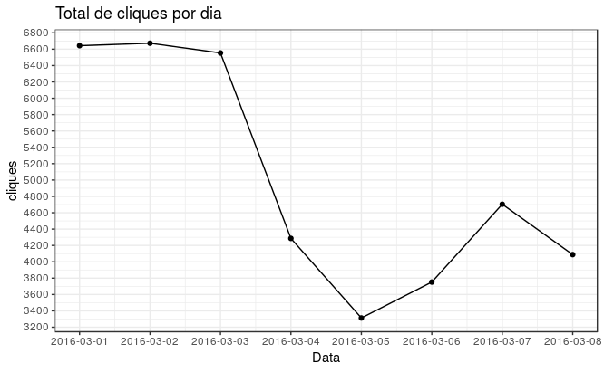

```r
#coluna dia day
buscas <- mutate(buscas, day = round_date(buscas$session_start_date, "day"))

#coluna data date
buscas <- mutate(buscas, date = as.Date(format(session_start_date, "%Y-%m-%d")))

cliques_por_dia_geral = buscas %>%
filter(num_clicks > 0) %>%
group_by(date) %>%
summarise(total_clicks = sum(num_clicks))

  ggplot(data=cliques_por_dia_geral, aes(x = date, y = total_clicks)) +
  geom_line() +
    geom_point() +
    scale_x_date(date_breaks = "1 day") +
    #scale_y_continuous(breaks = seq(0,10000,200), trans = "log10") +
    scale_y_continuous(breaks = seq(0,10000,200)) +
  labs(
      x = "Data",
      y = "cliques",
      title = "Total de cliques por dia")
```

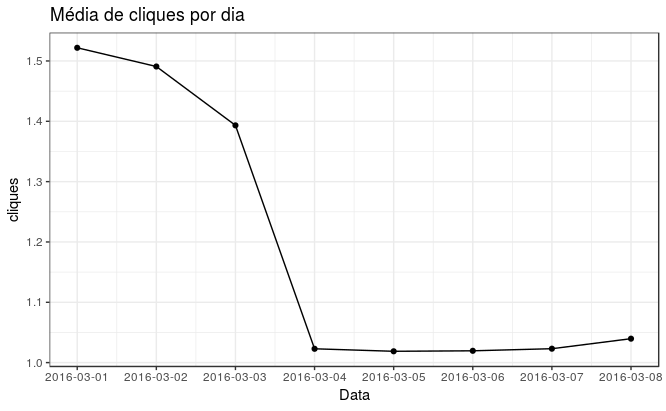

```r
  media_cliques_por_dia_geral = buscas %>%
filter(num_clicks > 0) %>%
group_by(date) %>%
summarise(media_total_clicks = mean(num_clicks))


  ggplot(data=media_cliques_por_dia_geral, aes(x = date, y = media_total_clicks)) +
  geom_line() +
    geom_point() +
    scale_x_date(date_breaks = "1 day") +
    #scale_y_continuous(breaks = seq(0,10000,200), trans = "log10") +
    #scale_y_continuous(breaks = seq(0,10000,200)) +
  labs(
      x = "Data",
      y = "cliques",
      title = "Média de cliques por dia")
```

Vamos analisar o número geral de cliques e a média de cliques apenas quando o usuário clica em alguma coisa, ou seja, quando num_clicks > 0 por grupo.

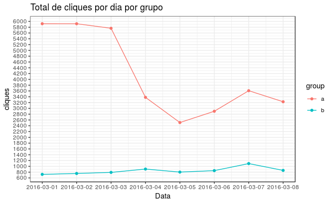

```r
cliques_por_dia_geral = buscas %>%
filter(num_clicks > 0) %>%
group_by(date, group) %>%
summarise(total_clicks = sum(num_clicks))

  ggplot(data=cliques_por_dia_geral, aes(x = as.Date(date), y = total_clicks, color = group)) +
  geom_line() +
    geom_point() +
    scale_x_date(date_breaks = "1 day") +
    #scale_y_continuous(breaks = seq(0,10000,200), trans = "log10") +
    scale_y_continuous(breaks = seq(0,6000,200)) +
  labs(
      y = "cliques",
      x = "Data",
      title = "Total de cliques por dia por grupo")
```

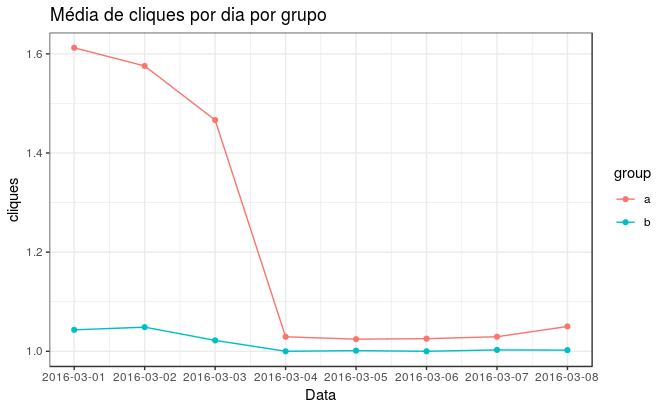

```r
  media_cliques_por_dia_geral = buscas %>%
filter(num_clicks > 0) %>%
group_by(date, group) %>%
summarise(media_total_clicks = mean(num_clicks))


  ggplot(data=media_cliques_por_dia_geral, aes(x = as.Date(date), y = media_total_clicks, color = group)) +
  geom_line() +
    geom_point() +
    scale_x_date(date_breaks = "1 day") +
    #scale_y_continuous(breaks = seq(0,10000,200), trans = "log10") +
    #scale_y_continuous(breaks = seq(0,0.6,0.1)) +
  labs(
      y = "cliques",
      x = "Data",
      title = "Média de cliques por dia por grupo")
```

### 2) Quais resultados as pessoas tendem a experimentar primeiro? Como isso muda no dia-a-dia?

Vamos observar a distribuição de qual resultado as pessoas clicam primeiro por grupo. Pela distribuição, vemos que a maior parte experimentam os resultados de 1 a 7.

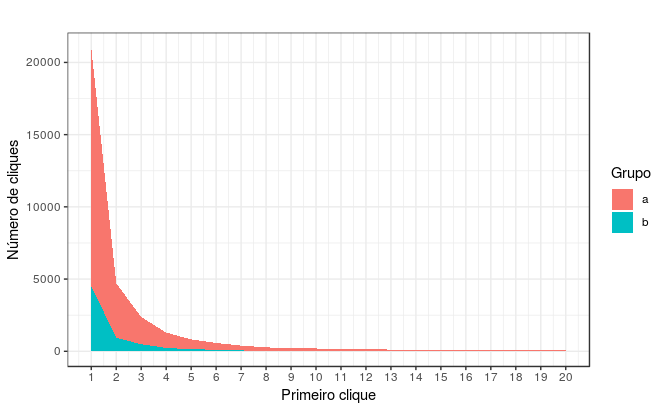

```r
buscas %>%
    filter(!is.na(first_click), first_click<=20) %>%
    count(first_click, group) %>%
    ggplot(aes(x = first_click, y = n, fill = group)) +
    geom_area() +
    #scale_x_continuous(breaks = seq(0,20,1), trans = "log10")
    scale_x_continuous(breaks = seq(0,20,1)) +
    labs(
      x = "Primeiro clique",
      y = "Número de cliques",
      fill = "Grupo",
      title = "")
```

### 3) Qual é a nossa taxa de resultados zero no geral? Como isso varia entre os grupos?

Vamos observar o número de resultados zero a cada dia por grupo e geral. Depois, vamos visualizar a média de resultados zero a cada dia por grupo e geral.

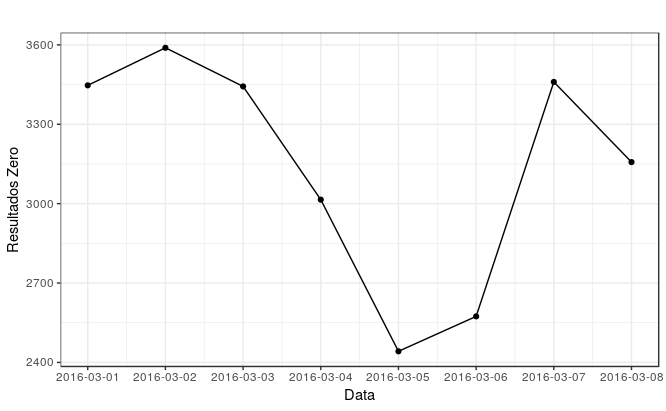

```r
resultado_zero_diario_geral = buscas %>%
                        filter(results==0) %>%
                            group_by(date) %>%
                                summarise(numero_resultado_zero_geral=n())

resultado_total_diario_geral = buscas  %>%
                        group_by(date) %>%
                            summarise(total_resultados_geral=n())

resultado_zero_diario_grupo = buscas %>%
                        filter(results==0) %>%
                            group_by(date, group) %>%
                                summarise(numero_resultado_zero_grupo=n())

resultado_total_diario_grupo = buscas  %>%
                        group_by(date, group) %>%
                            summarise(total_resultados_grupo=n())



calculo_taxa_resultado_zero_geral = resultado_zero_diario_geral %>%
                            inner_join(resultado_total_diario_geral, by=c("date")) %>%
                                mutate(taxa_resultado_zero_geral = numero_resultado_zero_geral/total_resultados_geral)

calculo_taxa_resultado_zero_grupo = resultado_zero_diario_grupo %>%
                            inner_join(resultado_total_diario_grupo, by=c("date", "group")) %>%
                                mutate(taxa_resultado_zero_grupo = numero_resultado_zero_grupo/total_resultados_grupo)


ggplot(data=resultado_zero_diario_geral, aes(x=date, y=numero_resultado_zero_geral))+
geom_line() +
geom_point() +
  scale_x_date(date_breaks = "1 day") +
  #scale_y_continuous(breaks = seq(0,2600,100)) +
  labs(title = "",
       x = "Data",
       y="Resultados Zero",
       group = "")
```

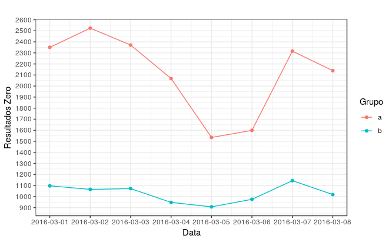

```r
ggplot(data=resultado_zero_diario_grupo, aes(x=date, y=numero_resultado_zero_grupo, group=group, color=group))+
geom_line() +
geom_point() +
  scale_x_date(date_breaks = "1 day") +
  scale_y_continuous(breaks = seq(0,2600,100)) +
  labs(title = "",
       x = "Data",
       y="Resultados Zero",
       group = "Grupo",
       color = "Grupo")
```

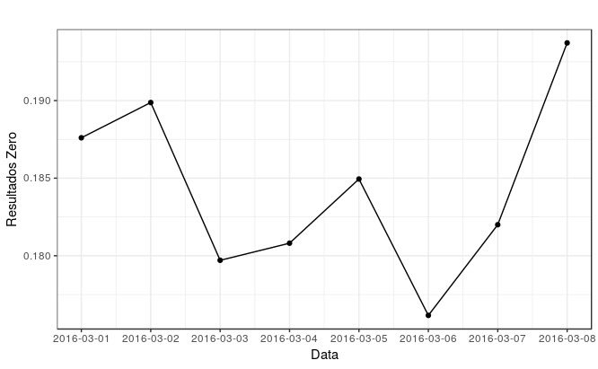

```r
ggplot(data=calculo_taxa_resultado_zero_geral, aes(x=date, y=taxa_resultado_zero_geral))+
geom_line() +
geom_point() +
  scale_x_date(date_breaks = "1 day") +
  #scale_y_continuous(breaks = seq(0,2600,100)) +
  labs(title = "",
       x = "Data",
       y="Resultados Zero",
       group = "")
```

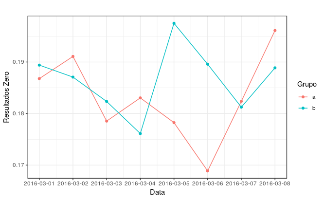

```r
ggplot(data=calculo_taxa_resultado_zero_grupo, aes(x=date, y=taxa_resultado_zero_grupo, group=group, color=group))+
geom_line() +
geom_point() +
  scale_x_date(date_breaks = "1 day") +
  #scale_y_continuous(breaks = seq(0,2600,100)) +
  labs(title = "",
       x = "Data",
       y="Resultados Zero",
       group = "Grupo",
       color = "Grupo")
```

### 4) Seja a duração da sessão aproximadamente o tempo entre o primeiro e o último evento de uma sessão. Escolha uma variável do conjunto de dados e descreva sua relação com o tamanho da sessão. Visualize o relacionamento.

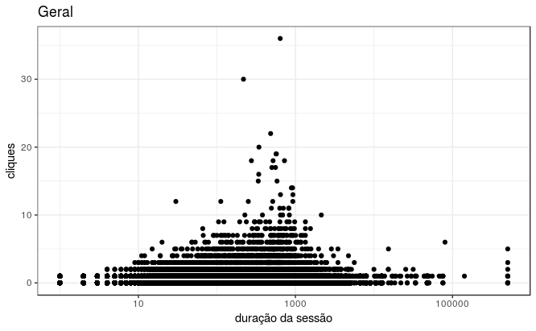

```r
cor_buscas_geral = buscas %>%
    filter (!is.na(session_length), session_length != 0)

    ggplot(data = cor_buscas_geral, aes(x = session_length, y = num_clicks)) +
    geom_point() +
    scale_x_continuous(trans = 'log10') +
    #facet_wrap(~ group)  +
    labs(
        x = "duração da sessão",
        y = "cliques",
        title = "Geral")
```

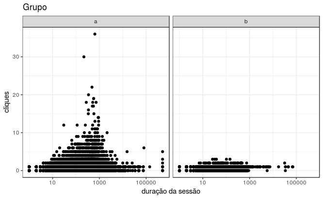

```r
cor_buscas_grupo = buscas %>%
    filter (!is.na(session_length), session_length != 0)

    ggplot(data = cor_buscas_grupo, aes(x = session_length, y = num_clicks)) +
    geom_point() +
    scale_x_continuous(trans = 'log10') +
    facet_wrap(~ group)  +
    labs(
        x = "duração da sessão",
        y = "cliques",
        title = "Grupo")
```

```r
#
# busca_geral_cor = cor_buscas_geral %>%
#     summarise(
#     pearson = cor(session_length, num_clicks, method = "pearson"),
#     spearman = cor(session_length, num_clicks, method = "spearman"),
#     kendall = cor(session_length, num_clicks, method = "kendall")
#   )
#
# busca_grupo_a_cor = buscas %>%
#     filter(group == 'a') %>%
#     summarise(
#     pearson = cor(session_length, num_clicks, method = "pearson"),
#     spearman = cor(session_length, num_clicks, method = "spearman"),
#     kendall = cor(session_length, num_clicks, method = "kendall")
#   )
#
# busca_grupo_b_cor = buscas %>%
#     filter(group == 'b') %>%
#     summarise(
#     pearson = cor(session_length, num_clicks, method = "pearson"),
#     spearman = cor(session_length, num_clicks, method = "spearman"),
#     kendall = cor(session_length, num_clicks, method = "kendall")
#   )
```